# LCAT microbiome correlation

Cynthia Tang, modfied 9.28.22 BH

2022-09-24

# QC summary

> Earlier QC analysis suggest plate effects in which the overall fluorescence intensity in plate 2 was significantly lower than plate 1. Therefore, the subsequent analysis uses **Normalized LCAT activity**.

> LCAT activity was normalized to quality control (ERCC2 plasma) by taking the ratio of the Sample LCAT activity (390nm/470nm) / ERCC2 Plasma LCAT activity (390nm/470nm).

## Load Data

```r
plate.merge <- readRDS(here("LCAT","data","LCAT_summary_filter_223B.rds"))
```

# OTU table

At Genus level (fixed ID):

# LCAT Data

Pull Normalized LCAT ratios as vector.

# Repeated Measure Correlation

```r
rmcorrelation <- function(microbe, y, data){
    df <- data.frame(
        subject = factor(pdata$subject),
        microbe = log(data[microbe,]+1), # log-transformation
        LCAT = y
    )
    cor <- rmcorr(subject, measure1 = microbe, measure2 = LCAT, dataset = df)
}
```

Check the normality

```r
shapiro.test(LCAT)
```

```
##
##  Shapiro-Wilk normality test
##
## data:  LCAT
## W = 0.99335, p-value = 0.9589
```

```r
normality <- data.frame(
    shapiro.raw = apply(genus.cpm, 1, function(x)shapiro.test(x)$p.value),
    shapiro.log = apply(genus.cpm, 1, function(x)shapiro.test(log(x+1))$p.value)
)
datatable(normality) %>%
    formatSignif(columns = 1:2)
```

|  | shapiro.raw | shapiro.log |
| --- | --- | --- |
| Absiella | 2.21651036663984e-15 | 0.0102252327311413 |
| Acetivibrio | 0.00192370548692261 | 1.98548170873849e-05 |
| Achromobacter | 3.56361592783692e-17 | 7.78641783247246e-14 |
| Acidaminococcus | 2.12417002276504e-16 | 4.95510411271671e-10 |
| Actinomyces | 1.58749537059e-08 | 0.128096055272742 |
| Adlercreutzia | 1.11614909780359e-12 | 2.94817707219916e-09 |
| Aeromonas | 8.91951675696341e-20 | 1.76396680457019e-19 |
| Agathobaculum | 2.9585220915926e-09 | 0.622949418678066 |
| Akkermansia | 1.21222490087997e-14 | 3.47635579353556e-06 |
| Alistipes | 3.34512981215547e-05 | 5.14644120493264e-08 |

[output cut: 175 more lines]

LCAT data are normally distributed, but **most microbes data were NOT normally distributed.**

## Visulization (unadjusted p-values)

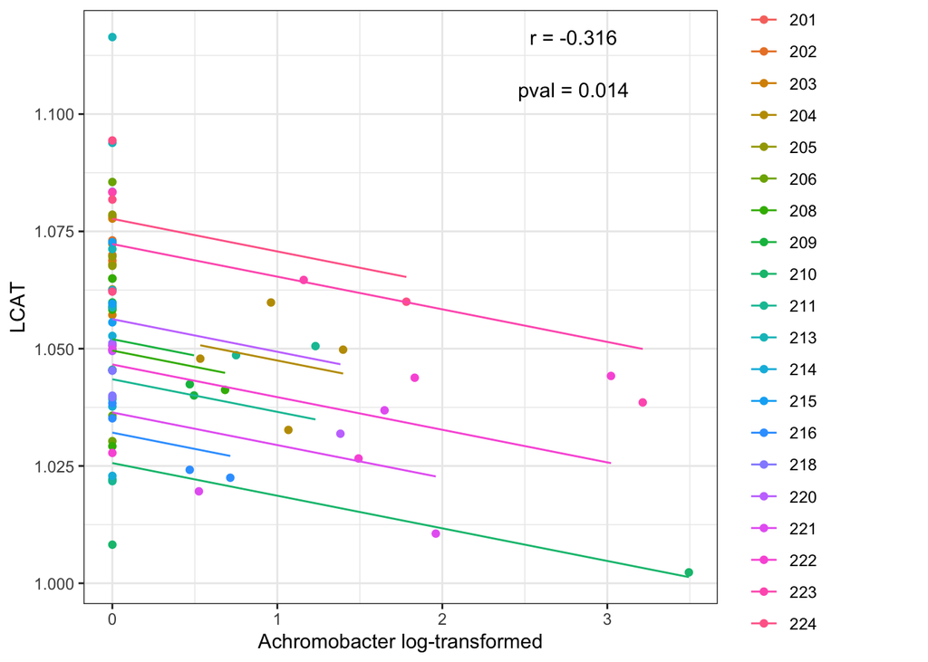

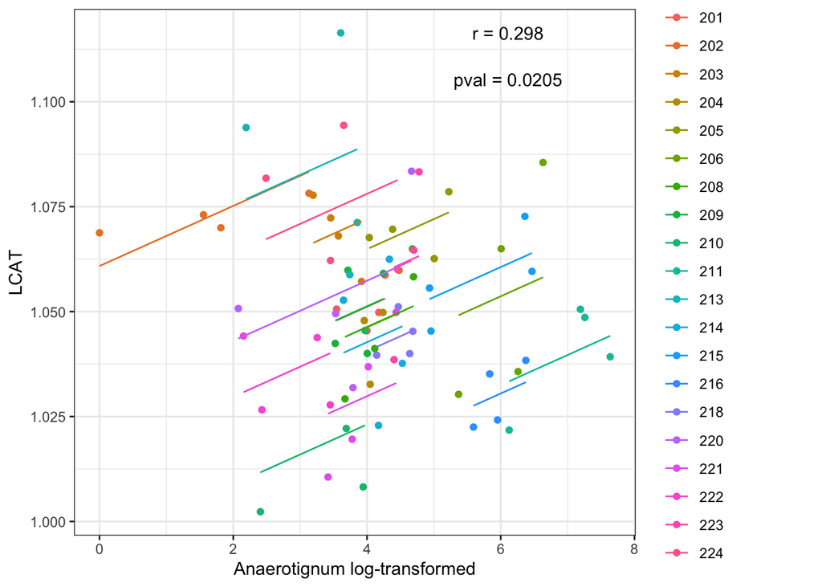

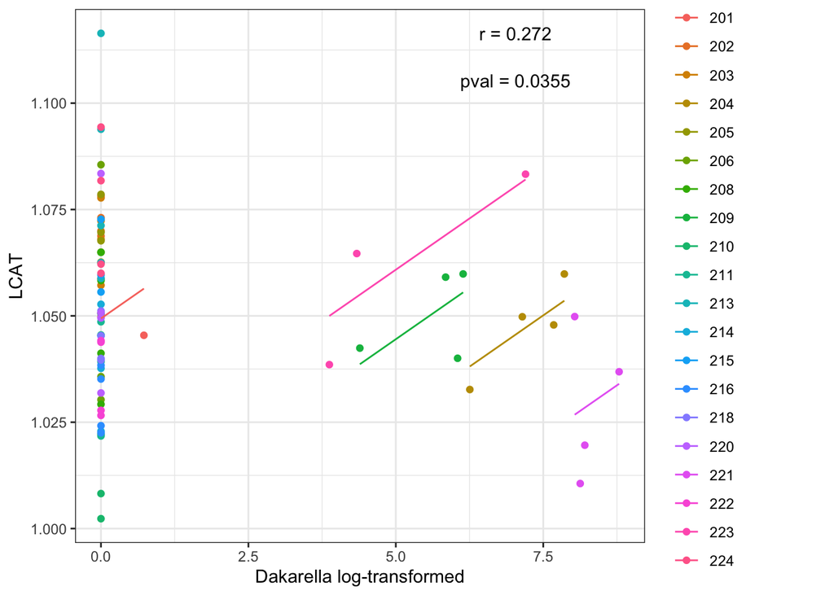

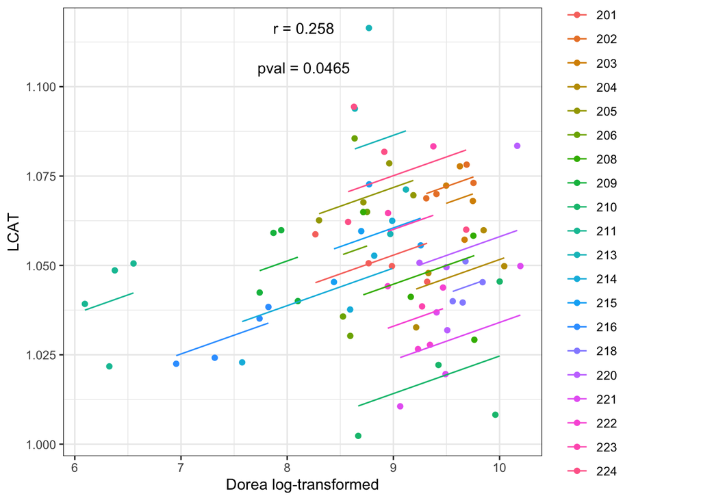

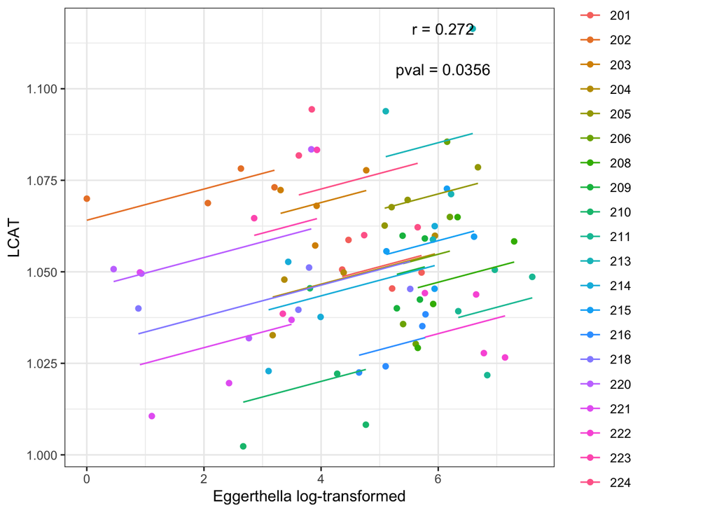

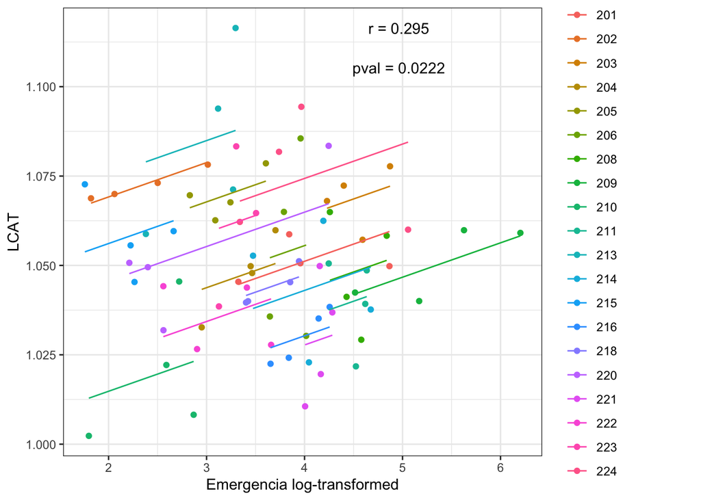

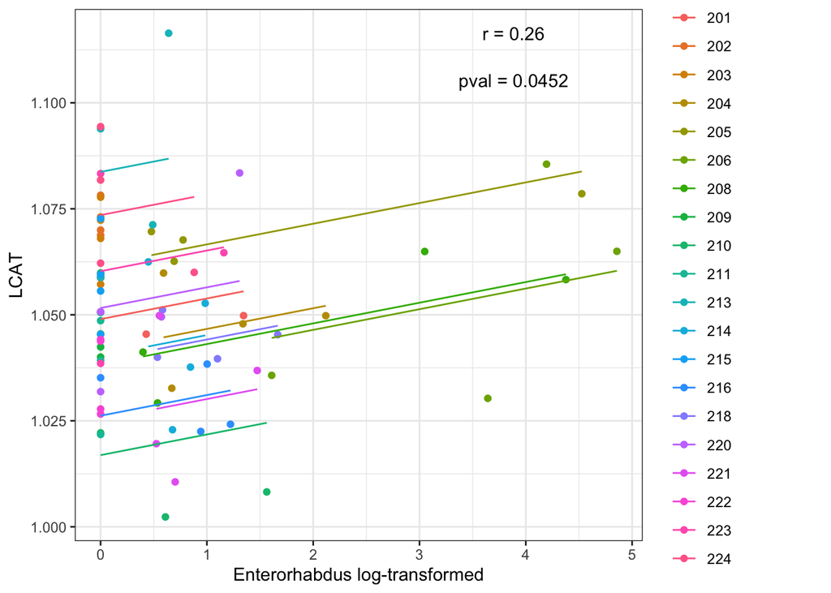

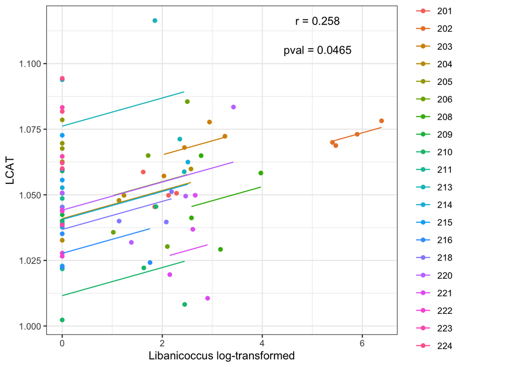

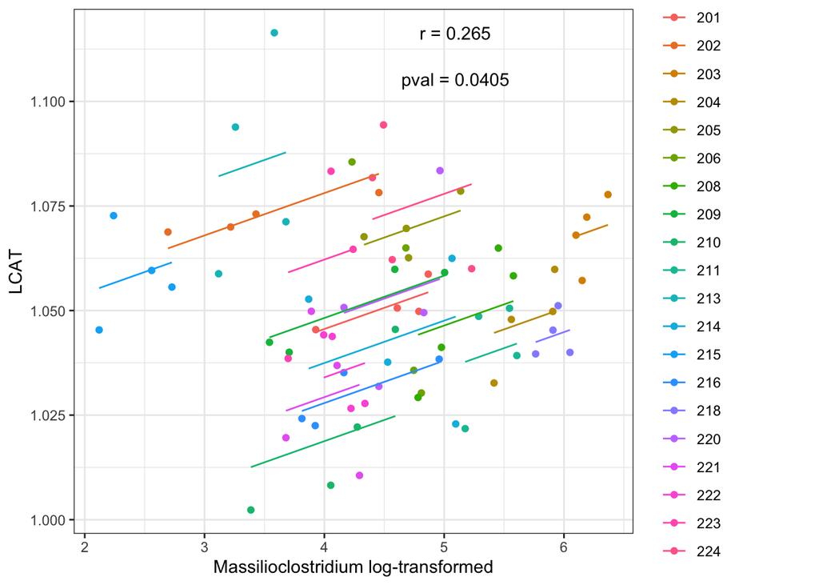

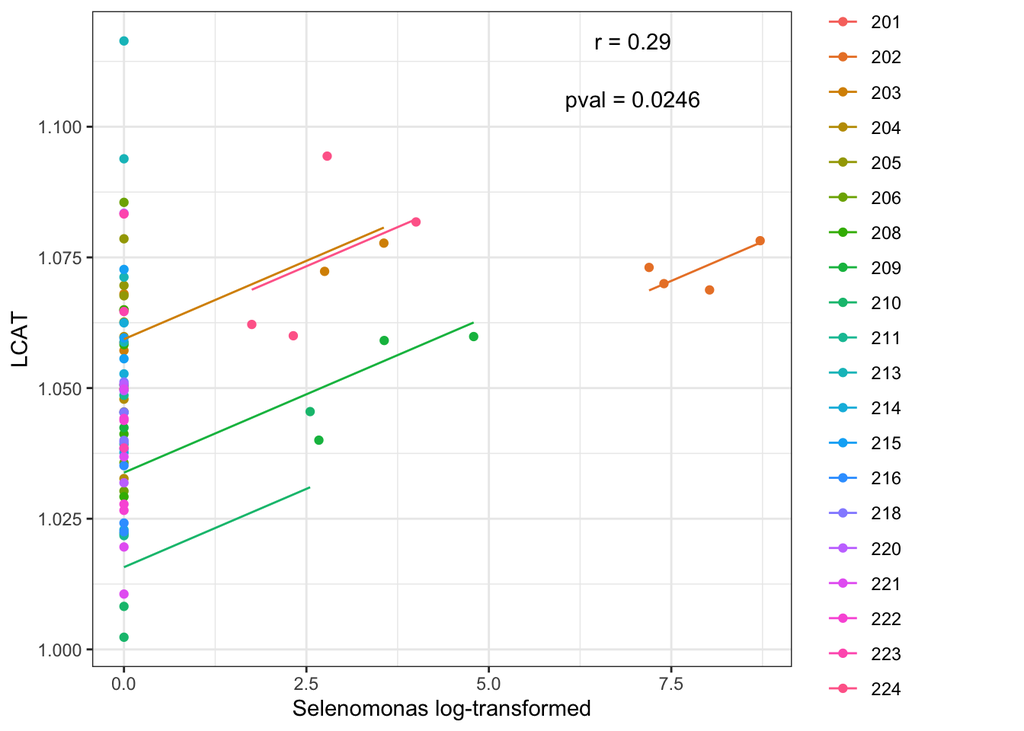

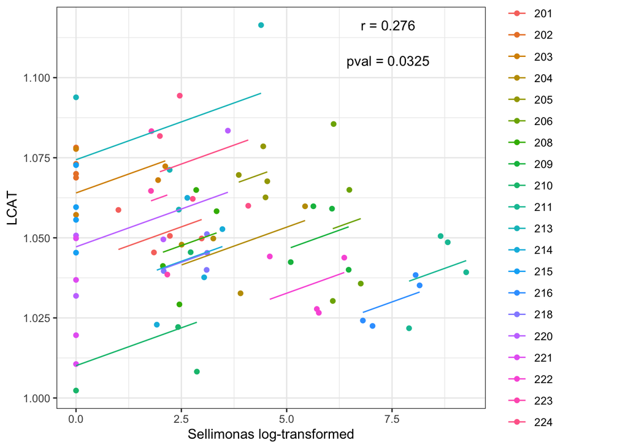

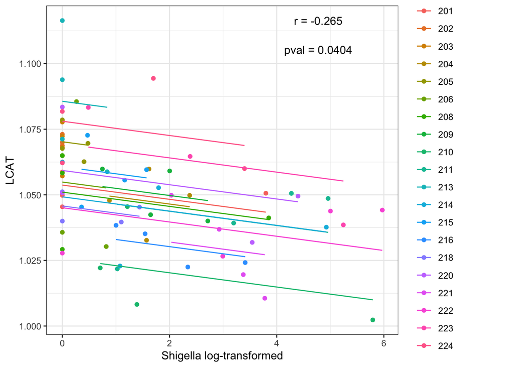

[2 more figures not shown]

```r
rmcor.plot <- function(x, xlab, ylab){
    df <- x$model$model
    p <- ggplot(df, aes(x = Measure1, y = Measure2)) +
        geom_point(aes(colour = factor(Participant), group = factor(Participant))) +
        geom_line(aes(y = x$model$fitted.values, group = factor(Participant), color = factor(Participant)), linetype = 1) +
        theme_bw() +
        labs(x = paste(xlab, "log-transformed"), y = ylab)
    xmax <- max(df$Measure1)
    ymax <- max(df$Measure2)
    p <- p +
        annotate(
            "text", x = xmax*0.8, y = c(ymax, ymax*0.99),
            label = paste0(c("r = ", "pval = "), signif(c(x$r, x$p), 3))
        )
    return(p)
}
plots <- lapply(rownames(genus.cpm)[which(pvals<0.05)], function(x){
    rmcor.plot(rmcor.res[[x]], xlab = x, ylab = "LCAT")
}) %>%
    `names<-`(rownames(genus.cpm)[which(pvals<0.05)])
plots
```

## Table of Repeated Measure Correlation

```r
rmcor.cpm <- data.frame(
    microbes = rownames(genus.cpm),
    rmcor = sapply(rmcor.res, function(x)x$r),
    pval = pvals,
    padj = padjs,
    sig = insight::format_p(padjs, name = NULL, stars_only = TRUE)
)
datatable(rmcor.cpm, colnames = c("Genus","Correlation (r)","p-value","Adjusted p-value","Sig level")) %>%
        formatRound(columns = "rmcor", digits = 2) %>%
        formatRound(columns = c("pval","padj"), digits = 3)
```

|  | Genus | Correlation (r) | p-value | Adjusted p-value | Sig level |
| --- | --- | --- | --- | --- | --- |
| Absiella | Absiella | 0.11228659051372 | 0.393006574691016 | 0.894901610052476 |  |
| Acetivibrio | Acetivibrio | -0.090909590678043 | 0.48969000843177 | 0.894901610052476 |  |
| Achromobacter | Achromobacter | -0.315719207243473 | 0.0139980597429124 | 0.612949318102869 |  |
| Acidaminococcus | Acidaminococcus | -0.0437479938988872 | 0.739964028302665 | 0.94287301669135 |  |
| Actinomyces | Actinomyces | 0.185753095907462 | 0.155325428817724 | 0.776627144088622 |  |
| Adlercreutzia | Adlercreutzia | 0.23423500030759 | 0.0716460713500157 | 0.653668764858409 |  |
| Aeromonas | Aeromonas | -0.0571222411770667 | 0.664641753536323 | 0.917602420927013 |  |
| Agathobaculum | Agathobaculum | 0.227396474126166 | 0.0805812408874024 | 0.653668764858409 |  |
| Akkermansia | Akkermansia | 0.0862128808717457 | 0.512483617544623 | 0.894901610052476 |  |
| Alistipes | Alistipes | -0.0781281826506442 | 0.552943016269363 | 0.894901610052476 |  |

[output cut: 175 more lines]

# Correlation analysis

Correlation between normalized(cpm) microbes (genus) OTU counts and LCAT concentration.

```r
top.hits <- filter(cor.count, padj<0.05) %>%
    arrange(desc(abs(cor))) %>%
    rownames()
top.hits.cpm <- filter(cor.cpm, padj<0.05) %>%
    arrange(desc(abs(cor))) %>%
    rownames()

# Are these hits overlapped?
# top.hits %in% top.hits.cpm
# overlapped genus
intersect(top.hits, top.hits.cpm)
```

```
##  [1] "Shigella"              "Escherichia"           "Achromobacter"
##  [4] "Selenomonas"           "Subdoligranulum"       "Phascolarctobacterium"
##  [7] "Barnesiella"           "Mitsuokella"           "Traorella"
## [10] "Dialister"             "Duodenibacillus"       "Negativibacillus"
## [13] "Lactococcus"           "Citrobacter"           "Faecalitalea"
## [16] "Intestinibacillus"     "Merdimonas"
```

We found a similar number of significant correlations between LCAT and normalized genus counts (cpm) compared to the previous raw count data. Most significant correlations found with counts were also detected with normalized counts.

## Correlation plot with Bifidobacterium Adjusted Pvalue

```
##  [1] "subject"        "timepoint_code" "gender"         "age"
##  [5] "Weight (kg)"    "Height (cm)"    "BMI (kg/m^2)"   "Systolic BP"
##  [9] "Diastolic BP"   "annotation"     "timepoint"      "trt"
```

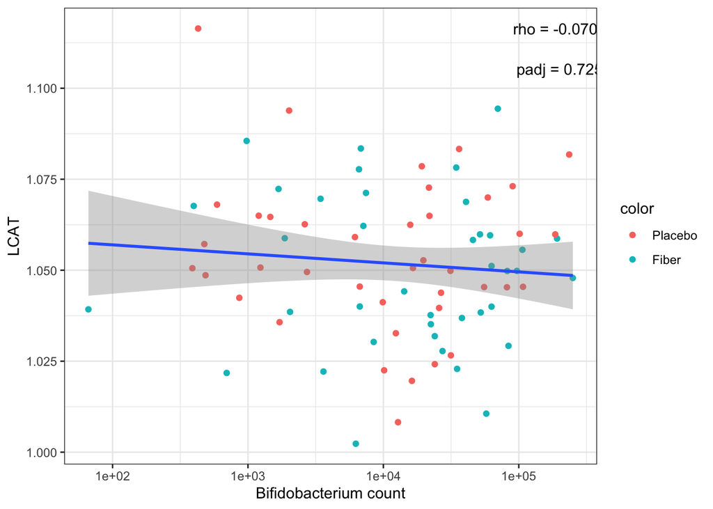

## All overlapped Correlation plot for Adjusted Pvalue < 0.05

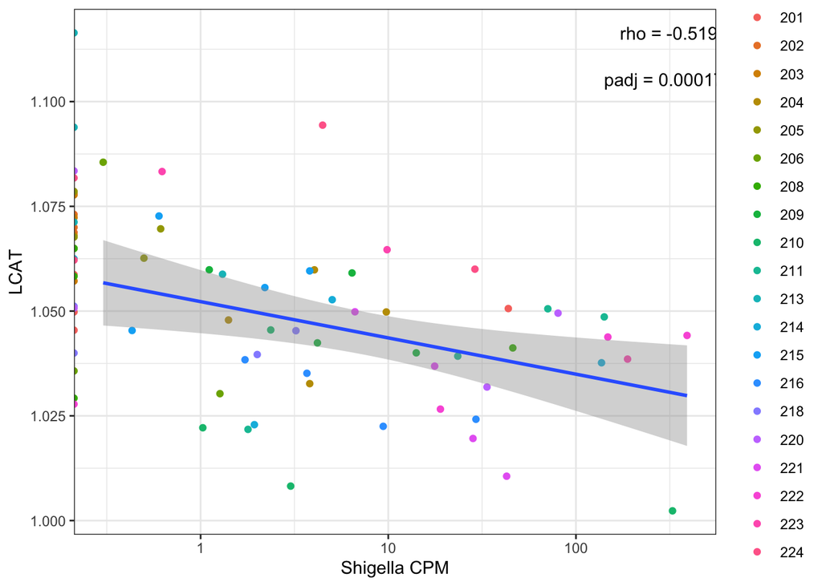

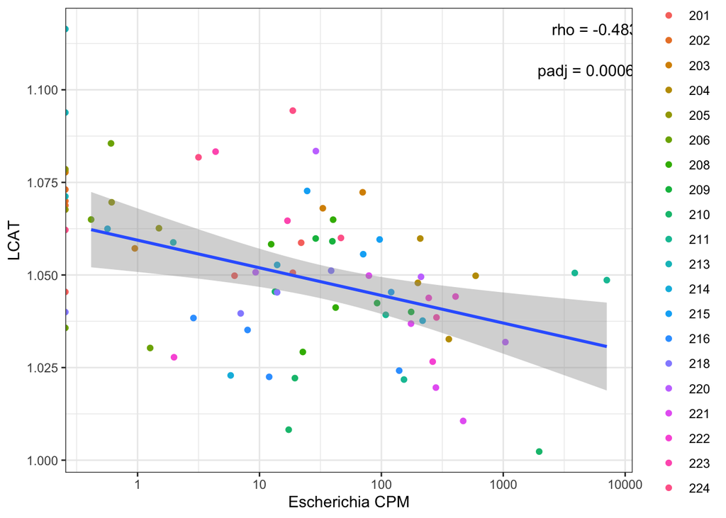

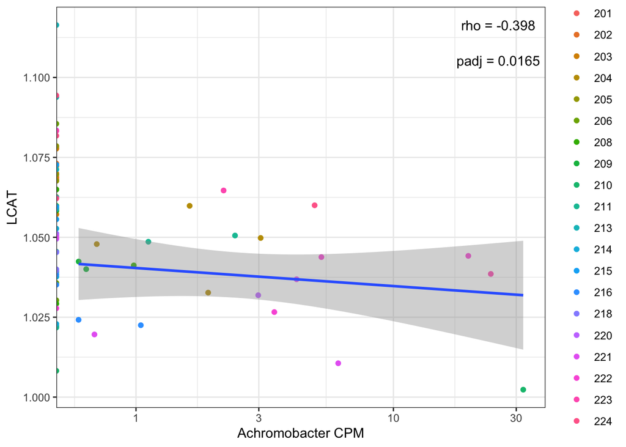

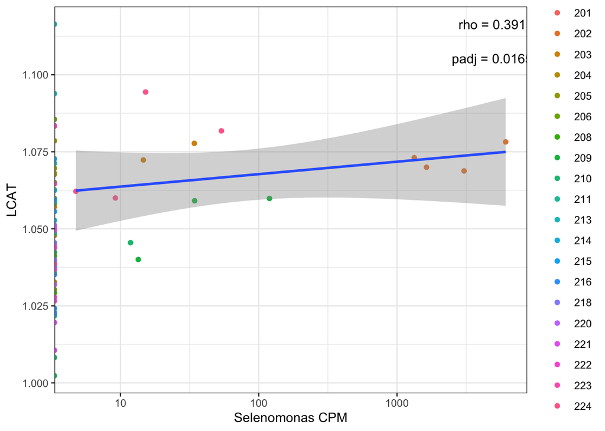

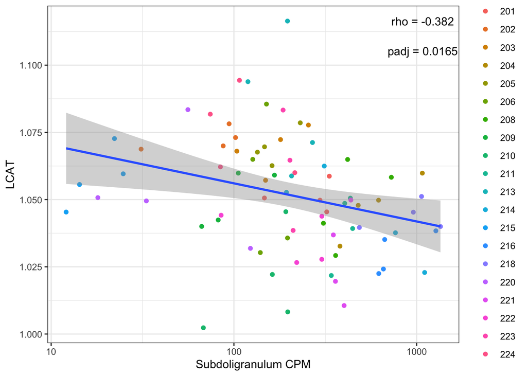

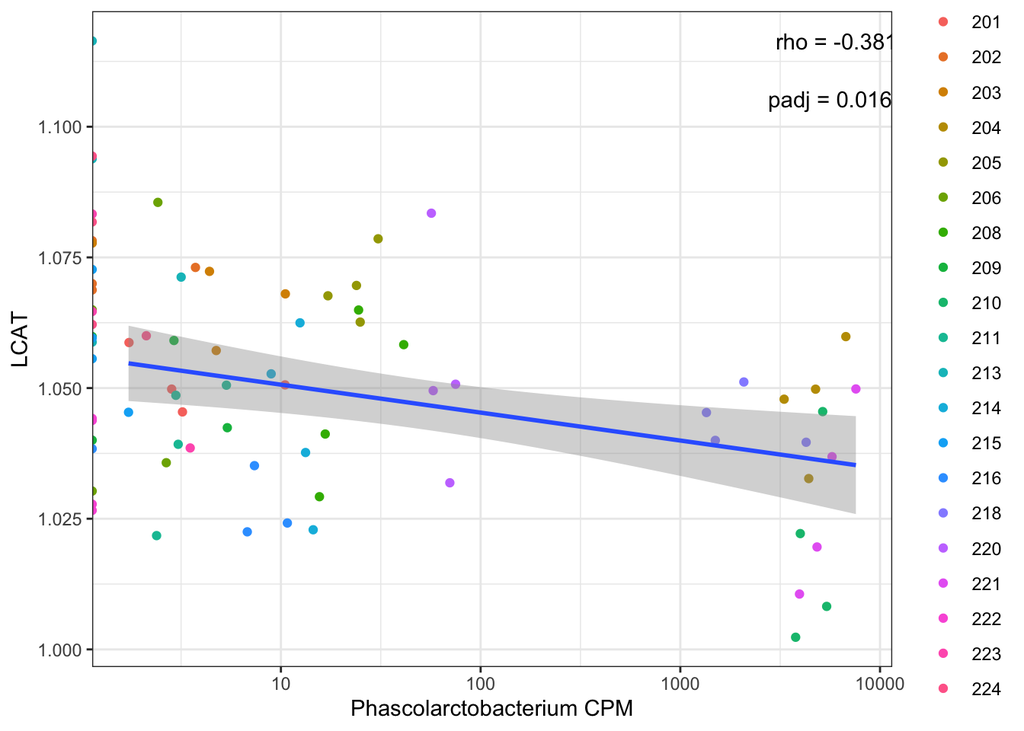

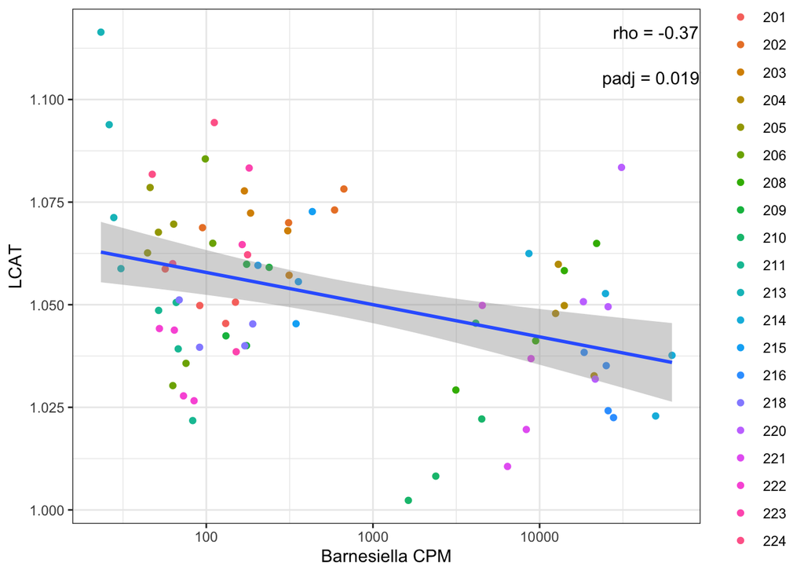

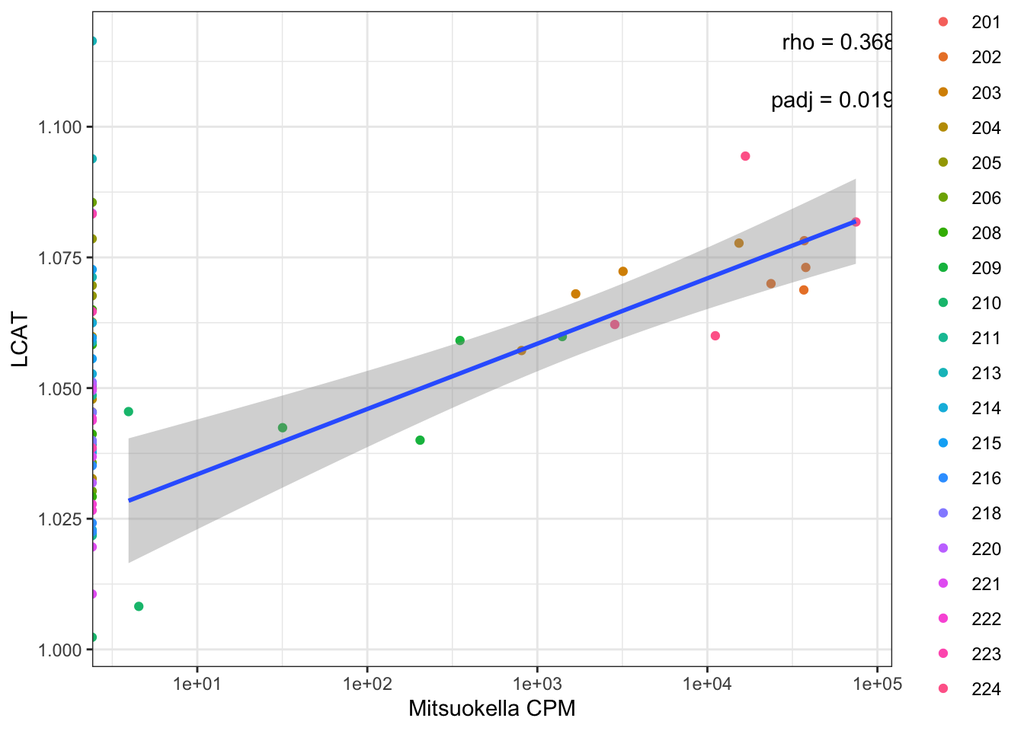

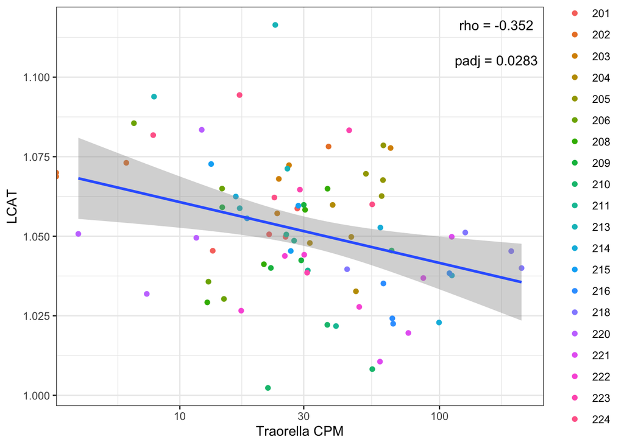

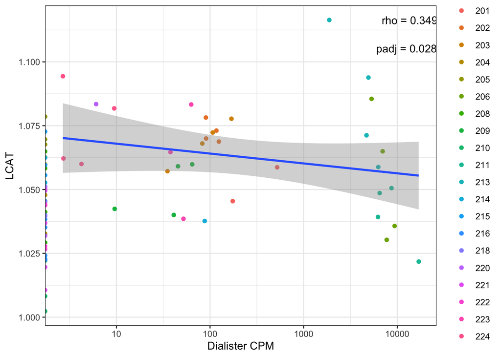

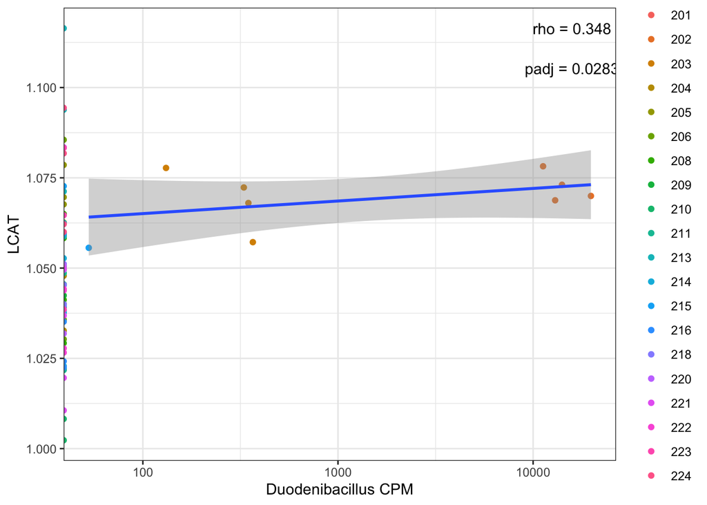

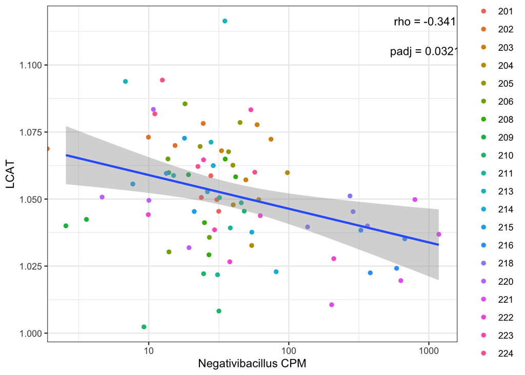

[5 more figures not shown]

## Table of Correlation (normalized)

```r
datatable(cor.cpm, colnames = c("Genus","Spearman Correlation (rho)","p-value","Adjusted p-value","Sig level")) %>%
        formatRound(columns = "cor", digits = 2) %>%
        formatRound(columns = c("pval","padj"), digits = 3)
```

| Genus | Spearman Correlation (rho) | p-value | Adjusted p-value | Sig level |
| --- | --- | --- | --- | --- |
| Absiella | -0.0845666991236612 | 0.458697406680866 | 0.678872161887682 |  |
| Acetivibrio | 0.0449367088607595 | 0.694143167081964 | 0.817939400701677 |  |
| Achromobacter | -0.40783016878307 | 0.000190965315650297 | 0.00883214584882622 | ** |
| Acidaminococcus | 0.07627641878189 | 0.504051992955673 | 0.699560111873654 |  |
| Actinomyces | 0.0574975657254138 | 0.614738937506207 | 0.778950023552386 |  |
| Adlercreutzia | 0.0656775228311875 | 0.565242972418241 | 0.745151767773084 |  |
| Aeromonas | -0.108061778750329 | 0.343157698570113 | 0.571929497616855 |  |
| Agathobaculum | -0.245886075949367 | 0.0289400748377694 | 0.154706620832748 |  |
| Akkermansia | -0.0241447520619127 | 0.832720748473032 | 0.915152777260228 |  |
| Alistipes | -0.267721518987342 | 0.0170628179495554 | 0.109411802955566 |  |

[output cut: 175 more lines]

## Table of Correlation (unnormalized)

```r
datatable(cor.count, colnames = c("Genus","Spearman Correlation (rho)","p-value","Adjusted p-value","Sig level")) %>%
        formatRound(columns = "cor", digits = 2) %>%
        formatRound(columns = c("pval","padj"), digits = 3)
```

| Genus | Spearman Correlation (rho) | p-value | Adjusted p-value | Sig level |
| --- | --- | --- | --- | --- |
| Absiella | -0.13638051242129 | 0.230736259952128 | 0.490646070013146 |  |
| Acetivibrio | -0.111437257365474 | 0.3282038354454 | 0.567455229508402 |  |
| Achromobacter | -0.398270427286606 | 0.000277877197998665 | 0.0164756150713636 | * |
| Acidaminococcus | 0.0664739314906902 | 0.56052614229904 | 0.746024002340449 |  |
| Actinomyces | 0.0192692769879236 | 0.866146831768086 | 0.942167248162969 |  |
| Adlercreutzia | 0.0709613536153507 | 0.534304029274771 | 0.72513438112584 |  |
| Aeromonas | -0.108061778750329 | 0.343157698570113 | 0.582423616839183 |  |
| Agathobaculum | -0.251060541930463 | 0.025629328447338 | 0.172177689442058 |  |
| Akkermansia | -0.0227876562298323 | 0.841997863595284 | 0.927200028363854 |  |
| Alistipes | -0.210686465433301 | 0.0623563717606551 | 0.295793045531313 |  |

[output cut: 175 more lines]

At family level: you can easily do this by changing “genus” in line 59 to “family” or any taxonomic levels you are interested in and re-run from the beginning.

```r
taxa <- readRDS(here("microbiome","data","taxa.rds"))
LCAT.id <- paste0(plate.merge$subject, plate.merge$treatment, plate.merge$timepoint)
taxa.id <- paste0(taxa$pdata$subject, tolower(taxa$pdata$trt), taxa$pdata$timepoint)

overlapped.id <- taxa.id %in% LCAT.id

genus <- summarize_feature(taxa, "family")[,overlapped.id]

pdata <- genus$pdata # metadata of subjects
genus <- genus$edata %>%
        `colnames<-`(taxa.id[overlapped.id]) # OTU count table at the genus level

var0 <- apply(genus, 1, function(x)var(x)==0) # remove genus with variance == 0

sum(var0)
```

```
## [1] 0
```

```r
genus <- genus[!var0, ]

## Remove Outlier (Sample # 74 / Sample ID 223B)
genus <- genus[, colnames(genus)!="223fiberpost"]
genus.cpm <- apply(genus, 2, function(x){x/sum(x)*1000000}) # total count = 1M
```

## Correlation analysis

Correlation between microbes (family) OTU counts and LCAT concentration.

These families (Selenomonadaceae, Alcaligenaceae, Enterobacteriaceae, Comamonadaceae) are overllaped in normalized and raw count data.

These (Barnesiellaceae, Streptococcaceae, Eubacteriaceae, Lachnospiraceae, Ruminococcaceae, Erysipelotrichaceae, Acidaminococcaceae, Selenomonadaceae, Veillonellaceae, Sutterellaceae, Alcaligenaceae, Enterobacteriaceae)are the families of significantly correlated genus.